# Effect of camera frame rate parameter on the total number of network packets

We need to analyse the impact of two possible values of camera frame rate on the total number of network packets. We have chosen two values for frame rate, namely, `20fps`, which is used in the primary experiments, and three times higher frame rate, `60fps`. First, let us load the necessary libraries:

```r
if (!require('tidyverse')) install.packages('tidyverse', dependencies = TRUE); library('tidyverse')
if (!require('ggpubr')) install.packages('ggpubr', dependencies = TRUE); library('ggpubr')
if (!require('rstatix')) install.packages('rstatix', dependencies = TRUE); library('rstatix')
if (!require('ggplot2')) install.packages('ggplot2', dependencies = TRUE); library('ggplot2')
```

Next, we load the raw data output of the performed experiment:

```r
data <- read.csv(file = '../../raw_data/test_frame_rate/run_table.csv')
data <- subset(data, select = c(X__run_id, frame_rate, num_of_packets))
data$frame_rate <- as.factor(data$frame_rate)
data$num_of_packets <- as.numeric(data$num_of_packets)
```

Mean and standard deviation of the total number of network packets for both frame rates are displayed in the summary below:

```r
data %>%
  group_by(frame_rate) %>%
  get_summary_stats(num_of_packets, type = "mean_sd")
```

| frame_rate | variable | n | mean | sd |
| --- | --- | --- | --- | --- |
| 20 | num_of_packets | 10 | 51786.3 | 3785.175 |
| 60 | num_of_packets | 10 | 30397.2 | 1323.201 |

We can visualize the distribution of the data for both frame rate treatments via boxplot below:

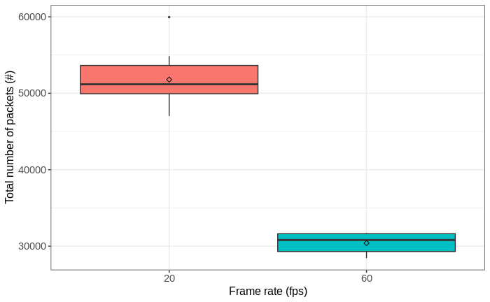

```r
#pdf(file = "../../figures/frame_rate_effect/number-of-packets.pdf")

ggplot(data, aes(x = frame_rate, y = num_of_packets, fill = frame_rate)) +
  theme_bw() +
  geom_boxplot(width = 0.9, outlier.size = 0.5) +
  stat_summary(fun = mean, color = 'black', geom = 'point', shape = 5, size = 1.5) +
  labs(x = "Frame rate (fps)", y = "Total number of packets (#)") +
  theme(legend.position = 'none') +
  theme(
    axis.title.x = element_text(size = 12, family = 'sans'),
    axis.title.y = element_text(size = 12, family = 'sans'),
    axis.text.x = element_text(size = 11, family = 'sans'),
    axis.text.y = element_text(size = 11, family = 'sans'),

  )
```

```r
#dev.off()
```

# Welch’s t-test

We will apply the Welch’s t-test to compare the means of both treatments. This is the default t-test in R and the safer alternative to standard Student’s t-test, when we cannot assume that variances of both treatments are equal. However, we still need to check if other assumptions for applying this test are met. The first assumption of having independent observations, i.e. each subject belongs to only one group and there are no relationships between observations within the two groups, is satisfied inherently by the very way in which the experiment is conducted.

## No significant outliers

Next assumption that we need to check is if there are no significant outliers in neither of the two groups:

```r
data %>%
  group_by(frame_rate) %>%
  identify_outliers(num_of_packets)
```

| frame_rate | X__run_id | num_of_packets | is.outlier | is.extreme |
| --- | --- | --- | --- | --- |
| 20 | run_9 | 59952 | TRUE | FALSE |

As the result above shows, there is one outlier, for run 9, but it is not considered extreme in terms of statistical significance. We can proceed with other assumptions.

## Normality

Next, we need to check if data in both groups stem from a normal distribution. To do so, we first need to draw QQ-plot for both groups:

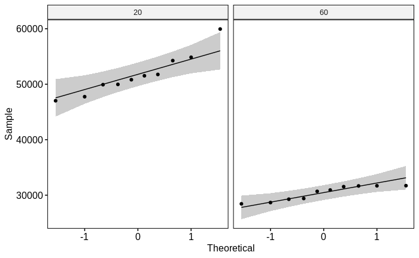

```r
ggqqplot(data, x = "num_of_packets", facet.by = "frame_rate")
```

Data points on both figures seem to be almost aligned alongside the respective reference lines, with some exceptions, hence we may assume that normality assumption is satisfied for both frame rate treatment groups. Nevertheless, we need to perform Shapiro-Wilk test for each group to confirm the assumptions drawn from the QQ-plots:

```r
data %>%
  group_by(frame_rate) %>%
  shapiro_test(num_of_packets)
```

| frame_rate | variable | statistic | p |
| --- | --- | --- | --- |
| 20 | num_of_packets | 0.9269299 | 0.41838226 |
| 60 | num_of_packets | 0.8492123 | 0.05684848 |

As the results of the test show, p-values for both groups are higher than `0.05` reference value (`p = 0.418` and `p = 0.057`, respectfully), which means that we cannot reject the null-hypothesis stating that the data within both groups are normally distributed. Hereby, we conclude that the normality assumption for both groups is satisfied.

## Computation

Since we established that there are no extreme outliers and the data for both groups is normally distributed, we can proceed with the execution of Welch’s t-test:

```r
data %>%
  t_test(num_of_packets ~ frame_rate) %>%
  add_significance()
```

|  | .y. | group1 | group2 | n1 | n2 | statistic | df | p | p.signif |
| --- | --- | --- | --- | --- | --- | --- | --- | --- | --- |
| 1 | num_of_packets | 20 | 60 | 10 | 10 | 16.86829 | 11.16728 | 2.69e-09 | **** |

The resulting p-value of $2.69 \cdot 10^{-9}$ is lower than `0.05` reference value for the `0.95` confidence interval. This means that the obtained p-value is statistically significant and we can reject $H_0$, which states that the means of the total number of network packets for both frame rate values are equal. We can hereby conclude that camera frame rate parameter has a statistically significant effect on the total number of network packets.

## Effect size

We established with Welch’s t-test result that camera frame rate parameter has a statistically significant effect on the total number of network packets. Now we need to perform Cohen’s d test to estimate the magnitude of the said effect:

```r
data %>%
  cohens_d(num_of_packets ~ frame_rate)
```

|  | .y. | group1 | group2 | effsize | n1 | n2 | magnitude |
| --- | --- | --- | --- | --- | --- | --- | --- |
| 1 | num_of_packets | 20 | 60 | 7.543727 | 10 | 10 | large |

[^1]: http://www.utstat.toronto.edu/~brunner/oldclass/378f16/readings/CohenPower.pdf
[^2]: https://digitalcommons.wayne.edu/cgi/viewcontent.cgi?article=1536&context=jmasm